# Finansteori (SFB30820), Høsten 2021

## Obligatorisk arbeidskrav

- Versjon 1.1
- Leveres ut: 28.09.2021 (Canvas)
- Leveres inn: 26.10.2021 (Canvas)
  - Del I: kan lastes opp som dokument-fil eller pdf.
  - Del II: som regneark (merk: svarene på tekstspørsmålene kan her føres rett inn i regnearket)

# Del I: Generelle forståelse og tradisjonelle oppgaver

## Oppgave 1: Generell forståelse (forsøk å svar så kortfattet og presist som mulig)

1. Forklare forskjellen mellom nåverdiutrykkene som benyttes for med og uten usikkerhet.

   Med usikkerhet vil selve formen på nåverdiuttrykket være det samme som uten usikkerhet. Imidlertid vil beregningene som utføres i teller og never være forskjellige. Med usikkerhet erstattes i telleren en sikker kontantstrøm av den forventede kontantstrømmen. I nevneren blir den risikofrie renten av risikojustert rente (kapitalkostnaden) som hensyntar både tidskostnaden og usikkerheten tilknyttet prosjektet.
2. Hva er forskjellen mellom forventet og realiserte verdi av en kontantstrøm?

   Den forventede kontantstrømmen gir oss forventningsverdien til en usikre kontanstrømmen *før* usikkerheten har blitt realisert. Den realiserte verdien gis ett av utfallene fra den usikre kontantstrømmen *etter* at usikkerheten har blitt realisert.
3. Ved vurdering av nye investeringprosjekter, forklar hvorfor det lett kan oppstå konflikt mellom forskjellige eiere i et selskap.

   Med flere eiere vil man typisk kunne oppleve at man har både uderversifiserte og veldiversifiserte eiere. Konflikt kan da lett oppstå siden de udiversifiserte ser forventet kontantstrøm fra det nye prosjektet i sammenheng med bedriftens allerede eksisterende kontantstrøm, mens de veldiversifiserte eierne ser forventet kontantstrøm fra det nye prosjektet i sammenheng med porteføljens eksisterende kontantstrøm
4. Hva menes med prosjektets eller aksjens beta?

   Dette er et mål for prosjektet eller aksjens systematiske risiko. I utgangsunktet kan risikoen til et prosjekt eller aksje splittes opp i usystemtatiske og systematisk risiko, hvor førstnevte utgjør den risikoen som man kan bli kvitt ved diversifisering. Den systematisk risiko utgjør den risikoen som da står igjen etter diversifisering. Den risikoen er drevet av makrofaktorer (eks. konjunkturer, pandemier, krig og fred) og kan forstås som forholdet mellom aksjens eller prosjektets risiko i forhold til markedsporteføljen. Formelt blir den beregnet som
   $$\beta_j=\frac{Kov(r_j,r_m)}{Var(r_m)}$$
   Hvor $\beta_j>1$ mer følsom enn markedsporteføljen, mens $\beta=1$ lik markedsporteføljen og $\beta<1$ mindre følsom en markedsporteføljen.
5. Gi en forklaring om mekanismene som ligger til grunn for Tofondsresultatet.

   Tofondsresultatet går ut på at (1) Uansett graden av risikoaversjon, setter alle investorer sammen sin aksjeportefølje på nøyaktig samme måte. (2) Den enkelte investors risikoaversjon avgjør bare hvor mye som totalt skal satses på den risikable komponenten framfor den risikofrie. Resultat oppstår fordi under antagelsen om risikoaversjon vil alltid en investor velge en kombiasjon av et risikofritt alternativ og den effisiente aksjeporteføljen M. Andre aksjeporteføljer medfører at investorene kostnadsfritt enten kan få sin risiko redusert og/eller få økt sin avkastning.
6. Forklar hvordan KVM er knyttet sammen med porteføljeteorien.

   I tillegg til forutsetningene som ligger bak porteføljeteorien ((1) risikoaversjon, (2) en periodisk horisont, (3) låne og spare til samme rente og (4) samme informasjon), antar også KVM at kapitalmarkedet er i likevekt, dvs. det beløpet som investorene i hvert selskapet tilsvarer den verdiveide markedsporteføljen. Dette gjør det mulig å prise *samtlige* aksjer som inngår i markedsporteføljen.
7. Gitt at KVM skal virke i praksis, er det da nødvendig at alle investorene tror på modellens forutsetninger (begrunn svaret)?

   Nei, paradoksalt trenger man noen aktører som ikke tror på modellens antagelser om informasjonseffisiens (dvs. at all relevant eksisterende informasjon er hensyntatt i aksjekursen) for at *feilprisede* aksjer skal korrigeres slik at antagelsen om kapitalmarkedet er i likevekt skal holde.
8. Hva menes med et finansielt instrument, og kan du gi noen eksemplar på bruken av dette?

   Er en kontrakt som består av to parter, hvor den ene parten mottar kapital fra den andre parten, mens den andre parten med det oppnår visse rettigheter ovenfor den andre parten. Finansielle instrumenter kan for eks. dreie seg om ulike typer lån (banklån og obligasjonslån) og finansielle derivater i form av opsjoner, forward, futures og swaps.
9. Hvordan kan teknisk et selskap øke forholdet mellom gjeld og egenkapital (kapitalstrukturen)?

   Forholdet mellom gjeld og egenkapital er gitt ved $G/E$ og kan isolert økes enten ved at $G$ går opp eller $E$ går ned. For $G$ gå opp kan skje ved ordinære lån eller obligasjonslån, mens for at $E$ skal gå ned ved at selskapet tilbakekjøper egne aksjer.

## Oppgave 2: Porteføljeteori to selskaper

For din portefølje har du mulighet til å investere et beløp på 10.000,- i selskap A og B. Avkastningen og sannsynligheten for de tre ulike tilstandene er gitt ved følgende tabell

|  | Tilstand | Sannsynlighet | Avkastning A | Avkastning B |
| --- | --- | --- | --- | --- |
|  | 1 | 0.5 | -0.1 | 0.2 |
|  | 2 | 0.2 | 0.5 | -0.3 |
|  | 3 | 0.3 | 0.2 | 0.1 |

1. Finn forventet avkastning, variansen og standardavviket til hvert enkelt av de to selskapene.
   1. Forventet avkastning:  
      $E(X_a)=-0.5\cdot 0.1 + 0.2\cdot 0.5+0.3\cdot 0.2=0.11$

   $E(X_b)=0.5\cdot 0.2 - 0.2\cdot 0.3+0.3\cdot 0.1=0.07$
2. Varians:

$Var(X_a)=0.5[-0.1-0.11]^2+ 0.2[0.5-0.11]^2 +0.3[0.2-0.11]^2=0.0549$  
$Var(X_b)=0.5[0.2-0.07]^2 + 0.2[-0.3-0.07]^2+0.3[0.1-0.07]^2=0.0361$

3. Standardavvik:

$Std(X_a)=\sqrt{0.0549}=0.2343075$  
$Std(X_b)=\sqrt{0.0361}=0.19$

1. Ta utgangspunkt i at 4.000,- av investeringsbeløpet investeres i selskap B, mens det resterende går til selskap A. Finn forventet avkastning, varians og standardavvik til porteføljen av de to selskapene.
   1. Vekter:  
      $w_b=4000/10000=0.4 \text{ } w_a=1-0.4=0.6$
   2. Forventet avkastning:  
      $E(r_p)$=0.6(0.11)+0.4(0.07) $=0.094$
   3. Varians:

$Std(rp)=\sqrt{0.005524}=0.0743236$

## Oppgave 3: Porteføljeteorien

I utgangspunktet har vi følgende opplysninger fra markedet som vi har analysert

|  |  | Forventet avkastning | Standardavik |
| --- | --- | --- | --- |
|  | Markedsporteføljen | 0.04 | 0.02 |
|  | Risikofri rente | 0.02 | 0 |

Både Ole Spetalen og Lise Sparegris har i utgangspunktet et beløp på 2.000.000,- som de ønsker å investere.

1. Vi har at $E(r_p)=wr_f+(1-w)E(r_m)$.  
   For Ole betyr dette at  
   $0.42=w\cdot 0.02 + (1-w)\cdot 0.04$  
   Som løst mhp. $w$ gir oss  
   $w=-19$ og $1-w=1+19=20$  
   Dette tilsvarer investeringsbeløp tilsvarerende $w=20\cdot 2.000.000=40.000.000$, hvor $38000000$ er som en følge av et risikofritt lån.
1. Lise Sparegris ønsker med god margin å sikre pensjonen sin. Ved bruk av samme porteføljeteori som Spetalen, hvordan vil hun fordele sine investeringer som forventet avkastning skal være på 2 prosent?

   For Lise betyr dette at  
   $0.02=w\cdot 0.02 + (1-w)\cdot 0.04$  
   Som løst mhp. $w$ gir oss  
   $w=1$ og $1-w=1-1=0$  
   Dette tilsvarer investeringsbeløp tilsvarerende $w=1\cdot 2.000.000=2.000.000$ i det risikofrie lånet.
1. Både får Ole og Lise finn varians og tilhørende standardavvik for deres respektive portefølje.

   For Ole  
   $Std(r_p)=20\cdot 0.02=0.4$  
   $Var(r_p)=0.4^2=0.16$  
   For Lise  
   $Std(r_p)=0\cdot 0.02=0$  
   $Var(r_p)=0^2=0$
1. Hvilken forutsetning om finansiering må være oppfylt for at Spetalen kan gjennomføre sin strategi, og er det helt sikkert at han vil oppnå en høyere avkastning enn det som Lise sikter imot?

   Vi forutsetter her (1) ingen kredittrestriksjoner og at (2) sparerenten er lik utlånsrenten.  
   Ole kan forvente å få høyere avkastning enn Lise, men det er usikkerhet knyttet til Oles strategi i motsetning til Lise. Om ikke sannsynlig, er det i alle fall mulig at den realiserte verdien gir ham en lavere avastning enn Lise.

## Oppgave 4: Kapitalverdimodellen og justert-nåverdi

Frøken Permanent er et lite AS som holder til på Halden Storsenter. Selskapet har som har som spesialitet microblading permanent makeup av bryn. I forbindelse med et oppkjøp er det estimert at selskapets egenkapitalbeta $\beta_E=0.90$ og gjeldsbeta lik $\beta_G=0.20$. Den risikofrie renten i markedet på $2.5$ prosent, mens markedets risikopremie anslås til 5 prosent og Bryns skattesats er lik 15 prosent. Totalt sett har Bryn AS 200 aksjer utestående med beregnet markedspris lik 1.500,-. Utestående gjeld er på 200.000,-

1. Basert på disse opplysningene, klarer du å finne totalkapitalkostnaden til selskapet?

   Framgangsmåte for å bestemme totalkapitalkostnaden til et selskap
   (1): Beregne vektene (markedsverdi) for egenkapital og gjeld
   $$w_E=\frac{300000}{300000+200000}=0.6\\
   w_G=\frac{200000}{300000+200000}=0.4$$
   (2): Kapitalkostnad for egenkapital
   $$k_E=r_f+\beta_E[E(r_m) - rf]= 0.025+0.90[0.05] = 0.07$$
   (3): Kapitalkostnad for gjeld
   $$k_G=r_f+\beta_G[E(r_m) - rf] = 0.025+0.20[0.05]= 0.035$$
   (4): Totalkapitalkostnad for selskapet
   $$k_T= k_Ew_E + k_G(1-s)w_G = 0.07\cdot 0.6 + 0.035\cdot (1-0.15)\cdot 0.4 = 0.0539$$
2. Dersom selskapet framover anslås å ha en evigvarende driftsresultat (OFR) på 100.000,-, hva er verdien til selskapet i dag?

   Uten skatt
   $$NV =\frac{100.000}{0.0539}=1855288$$
   Med skatt (helt korrekt)
   $$NV =\frac{(1-0.15)100.000}{0.0539}=1576.994$$

## Oppgave 5: Statsobligasjoner, terminrenter og rentens terminstruktur

### Obligasjoner

En obligasjon med 3 år til forfall har pålydende 5.000,-, kupongrente $r_k=0.07$ som utbetales n=1 ganger i året og årlige effektiv rente $r=0.06$.

1. Beregn prisen for en ordinær obligasjon.

   $$\begin{equation}
   P_0= \frac{Mr_k/n}{(1+r/n)^{1}} + \frac{Mr_k/n}{(1+r/n)^{2}} + \frac{Mr_k/n}{(1+r/n)^{3}}+\frac{M}{(1+r/n)^3}= \\
   \frac{350}{1+0.06}+\frac{350}{(1+0.06)^2}+\frac{350}{(1+0.06)^3}+\frac{5000}{(1+0.06)^3}=5133.651
   \end{equation}$$

En null-kupong-obligasjon med 4 år til forfall har pålydende 5.000,- med årlig effektiv rente $r=0.025$.

1. Beregn prisen for null-kupong rente obligasjonen

   Null-kupong obligasjoner (dvs. uten periodevise utbetalinger)
   $$\begin{equation}
   P_0=\frac{M}{(1+r)^T}=\frac{5000}{(1+0.025)^4}= 4529.753
   \end{equation}$$

### Rentens terminstruktur

Den kortsiktige spotrenten $_0r_1$ for ett år fram i tid er ved 1.5 prosent. Vider kan vi notere for null-kupongrente-obligasjoner for 2 og 3 år framover følgende opplysninger

[output not shown]

1. Hvilken sentral forutsetning ligger til grunn for at dette uttrykket holder ved likhet?

   Vi har her som utgangspunkt at en investor er *indifferent* mellom to alternative lån med samme sluttverdi.
1. Beregn terminrenten (forwardrenten) for 2 og 3 år framover i tid.

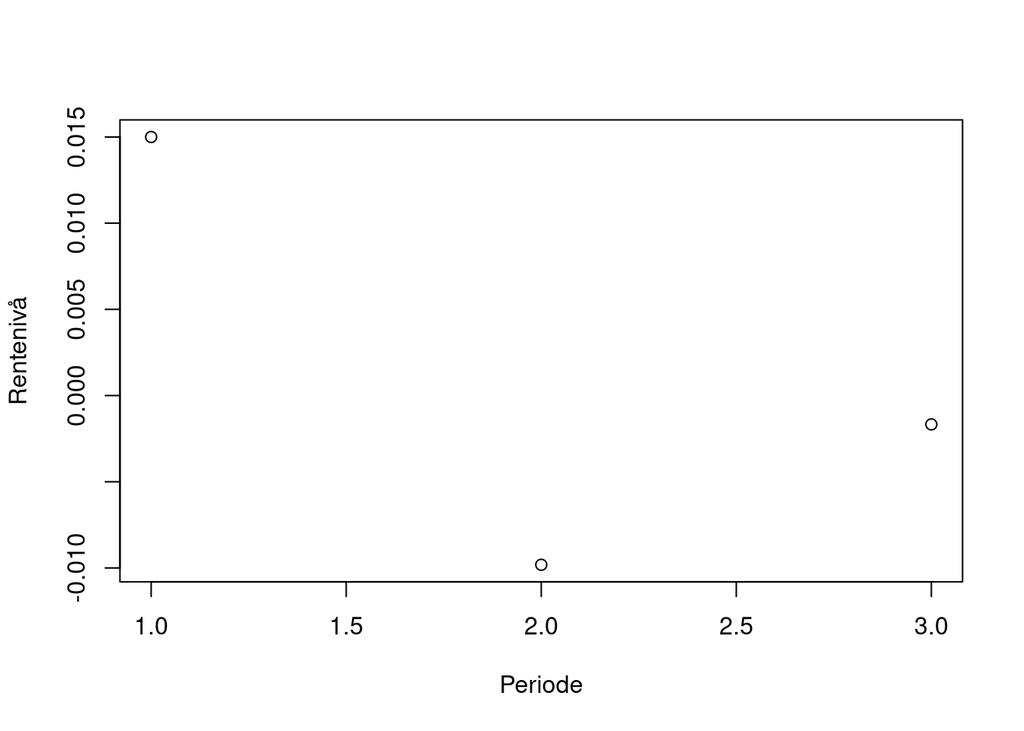

1. Kan du gi en kortfattet tolkning av hva denne kurven forteller oss?

   Dagens forventninger til framtidige korte renter er at de for to perioder framover vil synke til et neagativt nivå, for deretter i tredje periode hente seg noe opp igjen.